# Séance 4 : Manipuler les données

Nettoyer, joindre, remodeler, agréger — avant de conclure quoi que ce soit

Thierry Warin, PhD

HEC Montréal

## Plan · La séance

1. Deux questions de stratégie
2. Nettoyer : types, texte, doublons, valeurs manquantes
3. Joindre : `merge` et `concat`
4. Remodeler : format long, format large
5. Agréger : `groupby`, `agg`, `transform`
6. Le temps : décaler, croître, lisser
7. Les fusions-acquisitions créent-elles de la valeur ? Un premier regard

## À quoi sert la séance 4

### La stratégie

- Comparer une entreprise à **son** secteur plutôt qu’à la moyenne de tout le monde
- Lire la réaction de la Bourse à une annonce d’acquisition
- Savoir pourquoi un premier regard n’est **pas** une étude d’événement

### Le Python

- Corriger les types avec `astype`, `pd.to_numeric` et `.str`
- Joindre deux tables avec `merge(..., validate=, indicator=)`
- Passer du long au large avec `pivot` et `melt`
- Agréger avec `groupby().agg()` et `groupby().transform()`

### La méthode

- Compter les lignes **avant et après** chaque jointure
- Ne jamais remplir une valeur manquante sans le signaler
- Garder les données « rangées » : une ligne par observation

# Deux questions de stratégie

## « Qui sont mes vrais concurrents ? »

Dire « Tesla a un rendement des actifs de 14 % » ne veut rien dire tant qu’on ne sait pas **à qui** la comparer.

| Comparer à | Ce qu’il faut savoir faire |
| --- | --- |
| La moyenne de toutes les entreprises | `mean()` — facile, mais trompeur |
| La moyenne de **son secteur, la même année** | `groupby(["secteur", "annee"]).transform("mean")` |
| Les entreprises du même pays | `merge` avec une table de pays |

## « Les fusions-acquisitions créent-elles de la valeur ? »

Le 18 janvier 2022, Microsoft annonce l’acquisition d’Activision Blizzard. Le 13 mars 2023, Pfizer annonce celle de Seagen.

Pour regarder ce qu’en pense la Bourse, il faut :

1. **importer** des cours quotidiens (séance 3),
2. **calculer** des rendements, entreprise par entreprise,
3. **aligner** l’entreprise et le marché sur les mêmes dates,
4. **découper** une fenêtre autour de l’annonce, et **cumuler**.

Ce sont quatre opérations de manipulation. La méthode statistique complète — l’étude d’événement — viendra avec mes collègues (MacKinlay, 1997).

# Nettoyer

## Des données comme on les reçoit

```python
brut = pd.DataFrame({
    "Entreprise ": [" Tesla", "Ford", "ford", "General Motors", "Ford"],
    "Annee":       ["2023", "2023", "2023", "2023", "2023"],
    "Ventes (M$)": ["96 773", "176 191", "176 191", "157 658", "176 191"],
    "R&D":         ["3 969", "8 200", "8 200", "n.d.", "8 200"],
})
brut
```

|  | Entreprise | Annee | Ventes (M$) | R&D |
| --- | --- | --- | --- | --- |
| 0 | Tesla | 2023 | 96 773 | 3 969 |
| 1 | Ford | 2023 | 176 191 | 8 200 |
| 2 | ford | 2023 | 176 191 | 8 200 |
| 3 | General Motors | 2023 | 157 658 | n.d. |
| 4 | Ford | 2023 | 176 191 | 8 200 |

```python
brut.dtypes
```

```
Entreprise     str
Annee          str
Ventes (M$)    str
R&D            str
dtype: object
```

Tout est du texte (`object` ou `str`). On ne peut **rien** additionner.

## Étape 1 · Des noms de colonnes utilisables

```python
propre = brut.rename(columns={
    "Entreprise ": "entreprise",
    "Annee": "annee",
    "Ventes (M$)": "ventes",
    "R&D": "rd",
})
propre.columns.tolist()
```

```
['entreprise', 'annee', 'ventes', 'rd']
```

Règle du cours : noms en **minuscules**, sans accents, sans espaces ni symboles. `df.ventes` et `df["ventes"]` fonctionnent alors tous les deux, et personne ne cherche une espace invisible.

## Étape 2 · Le texte : `.str`

```python
propre["entreprise"] = propre["entreprise"].str.strip().str.title()
propre["entreprise"].tolist()
```

```
['Tesla', 'Ford', 'Ford', 'General Motors', 'Ford']
```

`.str` applique une méthode de texte à **chaque** cellule : `strip` retire les espaces aux extrémités, `title` met une majuscule à chaque mot, `lower`, `replace`, `contains`…

## Étape 3 · Les nombres : `astype` et `pd.to_numeric`

```python
propre["annee"] = propre["annee"].astype(int)
propre["ventes"] = propre["ventes"].str.replace(" ", "").astype(float)
propre["rd"] = pd.to_numeric(propre["rd"].str.replace(" ", ""), errors="coerce")
propre
```

|  | entreprise | annee | ventes | rd |
| --- | --- | --- | --- | --- |
| 0 | Tesla | 2023 | 96773.0 | 3969.0 |
| 1 | Ford | 2023 | 176191.0 | 8200.0 |
| 2 | Ford | 2023 | 176191.0 | 8200.0 |
| 3 | General Motors | 2023 | 157658.0 | NaN |
| 4 | Ford | 2023 | 176191.0 | 8200.0 |

`astype(float)` **échoue** sur `"n.d."`. `pd.to_numeric(..., errors="coerce")` le transforme en `NaN`. C’est voulu : vous **voyez** ensuite combien de valeurs ont été perdues.

## Étape 4 · Les doublons

```python
print(propre.duplicated().sum(), "ligne(s) en double")
propre = propre.drop_duplicates()
propre
```

```
2 ligne(s) en double
```

|  | entreprise | annee | ventes | rd |
| --- | --- | --- | --- | --- |
| 0 | Tesla | 2023 | 96773.0 | 3969.0 |
| 1 | Ford | 2023 | 176191.0 | 8200.0 |
| 3 | General Motors | 2023 | 157658.0 | NaN |

Sans l’étape 2, `"ford"` et `"Ford"` auraient été deux entreprises différentes. **L’ordre des étapes compte** : on normalise le texte, *puis* on cherche les doublons.

## Et dans les données du cours ?

```python
entreprises = pd.read_csv("data/entreprises.csv")
print(entreprises.duplicated(["ticker", "annee"]).sum(), "doublon entreprise × année")
entreprises.isna().sum()
```

```
0 doublon entreprise × année
```

```
ticker                0
entreprise            0
cik                   0
secteur               0
pays_siege            0
annee                 0
chiffre_affaires      3
resultat_net         11
actifs_totaux         5
capitaux_propres      3
rd                  135
investissements     121
dtype: int64
```

## Valeurs manquantes : trois stratégies

| Stratégie | Code | Quand |
| --- | --- | --- |
| **Retirer** | `dropna(subset=["rd"])` | La variable est indispensable à l’analyse |
| **Remplir** | `fillna(0)` | Vous **savez** que l’absence signifie zéro |
| **Signaler** | `df["rd_manquant"] = df["rd"].isna()` | Toujours, avant de retirer ou de remplir |

Amazon ne publie pas de ligne « R-D » ; elle dépense pourtant des dizaines de milliards en technologie. Remplir par zéro ferait d’Amazon l’entreprise la **moins** innovante du commerce de détail. **Ne remplissez jamais à l’aveugle.**

## Qui ne publie pas de R-D ?

```python
entreprises["rd_manquant"] = entreprises["rd"].isna()
(entreprises.groupby("entreprise")["rd_manquant"].mean()
    .loc[lambda s: s > 0].sort_values(ascending=False).round(2))
```

```
entreprise
Amazon              1.00
Coca-Cola           1.00
Costco              1.00
McDonald's          1.00
Nike                1.00
Starbucks           1.00
Target              1.00
Walmart             1.00
General Motors      0.73
Alphabet            0.20
Procter & Gamble    0.07
Name: rd_manquant, dtype: float64
```

Une valeur manquante est souvent une **information** : ici, sur la manière dont chaque entreprise présente ses comptes.

# Joindre

## Deux tables, une clé

```python
secteurs = pd.read_csv("data/secteurs.csv")
secteurs
```

|  | secteur | description |
| --- | --- | --- |
| 0 | Automobile | Constructeurs de véhicules, y compris électriques |
| 1 | Technologie | Logiciels, matériel, semi-conducteurs, platefo... |
| 2 | Commerce de détail | Distribution physique et en ligne |
| 3 | Pharmaceutique | Médicaments et produits de santé |
| 4 | Énergie | Pétrole et gaz intégrés |
| 5 | Biens de consommation | Boissons, hygiène, articles de sport |
| 6 | Restauration | Restauration rapide et cafés |
| 7 | Industrie | Aéronautique, machinerie, conglomérats industr... |
| 8 | Médias et divertissement | Diffusion en continu et contenus |

`entreprises` a une colonne `secteur` ; `secteurs` aussi. C’est la **clé** de la jointure.

## `merge` : la jointure

```python
avant = len(entreprises)
ent_sect = entreprises.merge(secteurs, on="secteur", how="left", validate="m:1")
print(avant, "→", len(ent_sect), "lignes")
ent_sect[["entreprise", "annee", "secteur", "description"]].head(3)
```

```
480 → 480 lignes
```

|  | entreprise | annee | secteur | description |
| --- | --- | --- | --- | --- |
| 0 | Tesla | 2010 | Automobile | Constructeurs de véhicules, y compris électriques |
| 1 | Tesla | 2011 | Automobile | Constructeurs de véhicules, y compris électriques |
| 2 | Tesla | 2012 | Automobile | Constructeurs de véhicules, y compris électriques |

- `how="left"` : on garde **toutes** les lignes de la table de gauche.
- `validate="m:1"` : plusieurs entreprises par secteur, **un seul** secteur par ligne de `secteurs`. Si ce n’est pas vrai, pandas **s’arrête** au lieu de dupliquer en silence.

## Les quatre façons de joindre

| `how=` | Garde | Usage typique |
| --- | --- | --- |
| `"inner"` | Les clés présentes **des deux côtés** | Analyse sur l’échantillon commun |
| `"left"` | Toutes les lignes de gauche | Ajouter des attributs à vos observations |
| `"right"` | Toutes les lignes de droite | Rare — inversez plutôt les tables |
| `"outer"` | Tout, des deux côtés | Diagnostiquer ce qui ne correspond pas |

**Comptez les lignes avant et après chaque jointure.** Un `merge` qui ajoute des lignes sans que vous l’ayez voulu est l’erreur la plus coûteuse — et la plus silencieuse — de l’analyse de données.

## Joindre les entreprises à leur pays

`pays_siege` contient `"USA"` ; `pays.csv` a une colonne `iso3`. Les noms diffèrent : on le dit.

```python
pays = pd.read_csv("data/pays.csv")
ent_pays = entreprises.merge(
    pays[["iso3", "annee", "pib_hab_usd", "croissance_pib"]],
    left_on=["pays_siege", "annee"], right_on=["iso3", "annee"],
    how="left", validate="m:1", indicator=True,
)
ent_pays["_merge"].value_counts()
```

```
_merge
both          448
left_only      32
right_only      0
Name: count, dtype: int64
```

## `indicator=True` : qui n’a pas trouvé de partenaire ?

```python
ent_pays.loc[ent_pays["_merge"] == "left_only", "annee"].value_counts()
```

```
annee
2024    32
Name: count, dtype: int64
```

Les 32 lignes orphelines sont toutes en **2024** : la Banque mondiale s’arrête en 2023 dans notre fichier. Ce n’est pas une erreur de code, c’est une **limite des données** — et `how="inner"` l’aurait cachée en supprimant une année entière.

## `concat` : empiler des tables

```python
tesla = entreprises[entreprises["ticker"] == "TSLA"]
ford = entreprises[entreprises["ticker"] == "F"]
auto = pd.concat([tesla, ford], ignore_index=True)
print(len(tesla), "+", len(ford), "=", len(auto))
```

```
15 + 15 = 30
```

|  | `merge` | `concat` |
| --- | --- | --- |
| Ajoute | des **colonnes** (côte à côte) | des **lignes** (les unes sous les autres) |
| Aligne sur | une clé | les noms de colonnes |

# Remodeler

## Des données « rangées »

Wickham (2014) : des données sont **rangées** (*tidy*) quand

1. chaque **variable** est une colonne,
2. chaque **observation** est une ligne,
3. chaque **type d’unité** est une table.

`entreprises.csv` est rangé : une ligne = une entreprise × une année. Mais beaucoup de sources — la Banque mondiale, Excel, les rapports annuels — publient un format **large** : une colonne par année.

## Du long au large : `pivot`

```python
large = (pays[pays["iso3"].isin(["CAN", "USA", "MEX", "CHN"]) & (pays["annee"] >= 2019)]
         .pivot(index="pays", columns="annee", values="pib_hab_usd")
         .round(0))
large
```

| annee pays | 2019 | 2020 | 2021 | 2022 | 2023 |
| --- | --- | --- | --- | --- | --- |
| Canada | 46353.0 | 43538.0 | 52887.0 | 56497.0 | 54848.0 |
| China | 10343.0 | 10627.0 | 12887.0 | 12971.0 | 12951.0 |
| Mexico | 10370.0 | 8841.0 | 10314.0 | 11406.0 | 13831.0 |
| United States | 65228.0 | 64465.0 | 71441.0 | 78009.0 | 82587.0 |

C’est le format de la Banque mondiale : lisible pour un humain, **inutilisable** pour un `groupby` ou un graphique par année.

## Du large au long : `melt`

```python
long = (large.reset_index()
        .melt(id_vars="pays", var_name="annee", value_name="pib_hab_usd"))
print(long.shape)
long.head(6)
```

```
(20, 3)
```

|  | pays | annee | pib_hab_usd |
| --- | --- | --- | --- |
| 0 | Canada | 2019 | 46353.0 |
| 1 | China | 2019 | 10343.0 |
| 2 | Mexico | 2019 | 10370.0 |
| 3 | United States | 2019 | 65228.0 |
| 4 | Canada | 2020 | 43538.0 |
| 5 | China | 2020 | 10627.0 |

`melt` est l’opération que vous ferez **le plus souvent** sur une donnée téléchargée.

## `pivot_table` : remodeler **et** agréger

```python
(entreprises
 .assign(marge=entreprises["resultat_net"] / entreprises["chiffre_affaires"])
 .pivot_table(index="secteur", columns="annee", values="marge", aggfunc="median")
 .loc[:, [2019, 2020, 2021, 2022, 2023]]
 .round(3))
```

| annee secteur | 2019 | 2020 | 2021 | 2022 | 2023 |
| --- | --- | --- | --- | --- | --- |
| Automobile | 0.001 | 0.023 | 0.105 | 0.067 | 0.062 |
| Biens de consommation | 0.088 | 0.156 | 0.159 | 0.143 | 0.145 |
| Commerce de détail | 0.029 | 0.036 | 0.046 | 0.022 | 0.032 |
| Industrie | 0.127 | 0.109 | 0.144 | 0.126 | 0.063 |
| Médias et divertissement | 0.093 | 0.110 | 0.172 | 0.142 | 0.160 |
| Pharmaceutique | 0.312 | 0.199 | 0.259 | 0.235 | 0.098 |
| Restauration | 0.209 | 0.143 | 0.235 | 0.184 | 0.223 |
| Technologie | 0.256 | 0.260 | 0.295 | 0.199 | 0.253 |
| Énergie | 0.056 | -0.126 | 0.100 | 0.151 | 0.109 |

`pivot` refuse les doublons ; `pivot_table` les **agrège** (ici, la médiane des entreprises du secteur).

# Agréger

## `groupby` + `agg` : un tableau par secteur

```python
(entreprises[entreprises["annee"] == 2023]
 .groupby("secteur")
 .agg(n=("ticker", "nunique"),
      ventes_mediane=("chiffre_affaires", "median"),
      rd_totale=("rd", "sum"),
      rd_publiee=("rd", "count"))
 .sort_values("ventes_mediane", ascending=False))
```

| secteur | n | ventes_mediane | rd_totale | rd_publiee |
| --- | --- | --- | --- | --- |
| Commerce de détail | 4 | 408537.5 | 0.0 | 0 |
| Énergie | 3 | 196913.0 | 1301.0 | 3 |
| Automobile | 3 | 157658.0 | 12169.0 | 2 |
| Technologie | 7 | 134902.0 | 172516.0 | 7 |
| Biens de consommation | 4 | 66684.0 | 2804.0 | 2 |
| Pharmaceutique | 4 | 55514.5 | 65608.0 | 4 |
| Industrie | 4 | 50034.5 | 7560.0 | 4 |
| Médias et divertissement | 1 | 33723.3 | 2675.8 | 1 |
| Restauration | 2 | 30734.8 | 0.0 | 0 |

L’**agrégation nommée** — `nom=(colonne, fonction)` — donne des colonnes lisibles d’un coup.

## `agg` réduit, `transform` conserve

|  | `agg` | `transform` |
| --- | --- | --- |
| Sortie | **une ligne par groupe** | **autant de lignes qu’au départ** |
| Usage | Un tableau de synthèse | Comparer chaque ligne à son groupe |

```python
entreprises["roa"] = entreprises["resultat_net"] / entreprises["actifs_totaux"]
entreprises["roa_secteur"] = (entreprises
                              .groupby(["secteur", "annee"])["roa"]
                              .transform("mean"))
entreprises["ecart_secteur"] = entreprises["roa"] - entreprises["roa_secteur"]
```

## Les vrais concurrents : l’écart au secteur

```python
(entreprises[entreprises["annee"] == 2023]
 [["entreprise", "secteur", "roa", "roa_secteur", "ecart_secteur"]]
 .sort_values("ecart_secteur", ascending=False)
 .round(3).head(8))
```

|  | entreprise | secteur | roa | roa_secteur | ecart_secteur |
| --- | --- | --- | --- | --- | --- |
| 118 | Nvidia | Technologie | 0.453 | 0.186 | 0.267 |
| 238 | Johnson & Johnson | Pharmaceutique | 0.210 | 0.076 | 0.134 |
| 433 | Caterpillar | Industrie | 0.118 | 0.014 | 0.104 |
| 58 | Apple | Technologie | 0.274 | 0.186 | 0.089 |
| 463 | Honeywell | Industrie | 0.092 | 0.014 | 0.078 |
| 13 | Tesla | Automobile | 0.140 | 0.064 | 0.076 |
| 373 | Nike | Biens de consommation | 0.153 | 0.119 | 0.035 |
| 313 | ConocoPhillips | Énergie | 0.114 | 0.097 | 0.017 |

## … et au bas du classement

```python
(entreprises[entreprises["annee"] == 2023]
 [["entreprise", "secteur", "roa", "roa_secteur", "ecart_secteur"]]
 .sort_values("ecart_secteur")
 .round(3).head(6))
```

|  | entreprise | secteur | roa | roa_secteur | ecart_secteur |
| --- | --- | --- | --- | --- | --- |
| 133 | Intel | Technologie | 0.009 | 0.186 | -0.177 |
| 448 | 3M | Industrie | -0.138 | 0.014 | -0.152 |
| 148 | IBM | Technologie | 0.055 | 0.186 | -0.130 |
| 253 | Merck & Co. | Pharmaceutique | 0.003 | 0.076 | -0.073 |
| 223 | Pfizer | Pharmaceutique | 0.009 | 0.076 | -0.067 |
| 28 | Ford | Automobile | 0.016 | 0.064 | -0.048 |

Microsoft a un rendement des actifs supérieur à celui de la plupart des 32 entreprises, mais **inférieur** à celui de son secteur en 2023. Le choix du groupe de comparaison change le diagnostic.

## Une limite à garder en tête

```python
entreprises.groupby("secteur")["ticker"].nunique().sort_values()
```

```
secteur
Médias et divertissement    1
Restauration                2
Automobile                  3
Énergie                     3
Biens de consommation       4
Commerce de détail          4
Industrie                   4
Pharmaceutique              4
Technologie                 7
Name: ticker, dtype: int64
```

Netflix est **seule** dans son secteur : son écart au secteur vaut zéro par construction. Une moyenne de groupe calculée sur une ou deux entreprises ne dit presque rien.

# Le temps

## Trier d’abord, décaler ensuite

```python
entreprises = entreprises.sort_values(["ticker", "annee"])
entreprises["ventes_an_prec"] = entreprises.groupby("ticker")["chiffre_affaires"].shift(1)
entreprises["croissance"] = entreprises.groupby("ticker")["chiffre_affaires"].pct_change()
(entreprises[entreprises["ticker"] == "TSLA"]
 [["annee", "chiffre_affaires", "ventes_an_prec", "croissance"]].tail(6).round(3))
```

|  | annee | chiffre_affaires | ventes_an_prec | croissance |
| --- | --- | --- | --- | --- |
| 9 | 2019 | 24578.0 | 21461.3 | 0.145 |
| 10 | 2020 | 31536.0 | 24578.0 | 0.283 |
| 11 | 2021 | 53823.0 | 31536.0 | 0.707 |
| 12 | 2022 | 81462.0 | 53823.0 | 0.514 |
| 13 | 2023 | 96773.0 | 81462.0 | 0.188 |
| 14 | 2024 | 97690.0 | 96773.0 | 0.009 |

Sans `groupby("ticker")`, `shift` prendrait l’année 2024 de *Tesla* comme « année précédente » de 2010 pour l’entreprise suivante. Dans un panel, on décale **toujours par entité**.

## Lisser : la moyenne mobile

```python
entreprises["croissance_3ans"] = (entreprises.groupby("ticker")["croissance"]
                                  .transform(lambda s: s.rolling(3).mean()))
(entreprises[entreprises["secteur"] == "Automobile"]
 .pivot(index="annee", columns="entreprise", values="croissance_3ans")
 .loc[2018:].round(3))
```

| entreprise annee | Ford | General Motors | Tesla |
| --- | --- | --- | --- |
| 2018 | 0.023 | -0.004 | 0.745 |
| 2019 | 0.009 | -0.063 | 0.550 |
| 2020 | -0.063 | -0.093 | 0.418 |
| 2021 | -0.047 | -0.049 | 0.378 |
| 2022 | 0.016 | 0.066 | 0.501 |
| 2023 | 0.115 | 0.136 | 0.469 |
| 2024 | 0.108 | 0.150 | 0.237 |

# Les F&A créent-elles de la valeur ?

## Importer les cours, une seule fois

```python
from pathlib import Path
import yfinance as yf

def cours(ticker, debut="2021-06-01", fin="2023-12-31"):
    """Cours de clôture ajustés, mis en cache dans data/cache/ au premier appel."""
    fichier = Path("data/cache") / f"{ticker}.parquet"
    if not fichier.exists():
        fichier.parent.mkdir(parents=True, exist_ok=True)
        d = yf.download(ticker, start=debut, end=fin, progress=False, auto_adjust=True)
        d.columns = [c[0] if isinstance(c, tuple) else c for c in d.columns]
        d.to_parquet(fichier)
    return pd.read_parquet(fichier)["Close"]

prix = pd.DataFrame({t: cours(t) for t in ["MSFT", "PFE", "SPY"]})
prix.tail(3).round(2)
```

| Date | MSFT | PFE | SPY |
| --- | --- | --- | --- |
| 2023-12-27 | 366.25 | 23.91 | 461.41 |
| 2023-12-28 | 367.44 | 24.06 | 461.58 |
| 2023-12-29 | 368.18 | 24.06 | 460.25 |

## Des prix aux rendements

```python
rendements = prix.pct_change().dropna()
rendements.describe().loc[["mean", "std", "min", "max"]].round(4)
```

|  | MSFT | PFE | SPY |
| --- | --- | --- | --- |
| mean | 0.0008 | -0.0002 | 0.0003 |
| std | 0.0179 | 0.0168 | 0.0114 |
| min | -0.0772 | -0.0672 | -0.0435 |
| max | 0.0823 | 0.1086 | 0.0550 |

`SPY` est un fonds indiciel qui réplique le S&P 500 : on l’utilise comme **le marché**.

## Rendement anormal, version naïve

$$\text{rendement anormal}_t = r_{\text{entreprise},t} - r_{\text{marché},t}$$

```python
def fenetre(ticker, annonce, avant=5, apres=5):
    r = rendements[[ticker, "SPY"]].copy()
    r["anormal"] = r[ticker] - r["SPY"]
    i = r.index.get_loc(pd.Timestamp(annonce))       # position du jour de l'annonce
    w = r.iloc[i - avant : i + apres + 1].copy()
    w["jour"] = range(-avant, apres + 1)
    w["cumul"] = w["anormal"].cumsum()
    return w

msft = fenetre("MSFT", "2022-01-18")
msft[["jour", "MSFT", "SPY", "anormal", "cumul"]].round(4)
```

| Date | jour | MSFT | SPY | anormal | cumul |
| --- | --- | --- | --- | --- | --- |
| 2022-01-10 | -5 | 0.0007 | -0.0012 | 0.0020 | 0.0020 |
| 2022-01-11 | -4 | 0.0023 | 0.0091 | -0.0068 | -0.0049 |
| 2022-01-12 | -3 | 0.0104 | 0.0027 | 0.0077 | 0.0029 |
| 2022-01-13 | -2 | -0.0423 | -0.0138 | -0.0285 | -0.0257 |
| 2022-01-14 | -1 | 0.0177 | 0.0004 | 0.0173 | -0.0084 |
| 2022-01-18 | 0 | -0.0243 | -0.0177 | -0.0066 | -0.0150 |
| 2022-01-19 | 1 | 0.0022 | -0.0104 | 0.0126 | -0.0024 |
| 2022-01-20 | 2 | -0.0057 | -0.0111 | 0.0054 | 0.0030 |
| 2022-01-21 | 3 | -0.0185 | -0.0196 | 0.0012 | 0.0042 |
| 2022-01-24 | 4 | 0.0011 | 0.0042 | -0.0031 | 0.0011 |
| 2022-01-25 | 5 | -0.0266 | -0.0122 | -0.0144 | -0.0133 |

## Pfizer et Seagen

```python
pfe = fenetre("PFE", "2023-03-13")
pfe[["jour", "PFE", "SPY", "anormal", "cumul"]].round(4)
```

| Date | jour | PFE | SPY | anormal | cumul |
| --- | --- | --- | --- | --- | --- |
| 2023-03-06 | -5 | -0.0010 | 0.0007 | -0.0017 | -0.0017 |
| 2023-03-07 | -4 | -0.0187 | -0.0153 | -0.0034 | -0.0051 |
| 2023-03-08 | -3 | -0.0055 | 0.0016 | -0.0071 | -0.0122 |
| 2023-03-09 | -2 | -0.0165 | -0.0184 | 0.0020 | -0.0102 |
| 2023-03-10 | -1 | -0.0018 | -0.0144 | 0.0127 | 0.0025 |
| 2023-03-13 | 0 | 0.0119 | -0.0014 | 0.0134 | 0.0159 |
| 2023-03-14 | 1 | 0.0010 | 0.0165 | -0.0155 | 0.0003 |
| 2023-03-15 | 2 | 0.0095 | -0.0063 | 0.0158 | 0.0161 |
| 2023-03-16 | 3 | 0.0022 | 0.0175 | -0.0153 | 0.0008 |
| 2023-03-17 | 4 | -0.0067 | -0.0117 | 0.0050 | 0.0058 |
| 2023-03-20 | 5 | 0.0177 | 0.0096 | 0.0081 | 0.0139 |

## Les deux fenêtres côte à côte

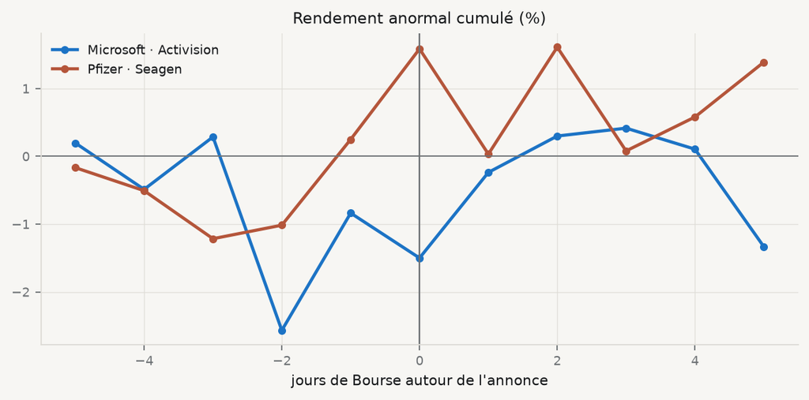

```python
from plotstyle import setup, CL
plt = setup()

fig, ax = plt.subplots()
ax.plot(msft["jour"], msft["cumul"] * 100, marker="o",
        color=CL.accent, label="Microsoft · Activision")
ax.plot(pfe["jour"], pfe["cumul"] * 100, marker="o",
        color=CL.warn, label="Pfizer · Seagen")
ax.axvline(0, color=CL.muted, lw=1)
ax.axhline(0, color=CL.muted, lw=0.8)
ax.set_xlabel("jours de Bourse autour de l'annonce")
ax.set_title("Rendement anormal cumulé (%)")
ax.legend(frameon=False)
plt.show()
```

## Ce que ce calcul n’est **pas**

| Ce premier regard | Une étude d’événement (MacKinlay, 1997) |
| --- | --- |
| Marché = SPY, bêta implicite de 1 | Modèle de marché estimé sur une **période d’estimation** |
| Deux annonces | Des centaines d’annonces, puis une moyenne |
| Aucun test | Un test statistique de l’anormalité |
| Fenêtre choisie à l’œil | Fenêtre justifiée, robustesse vérifiée |
| Ignore les fuites avant l’annonce | Les cherche explicitement |

Avec deux annonces et un écart-type quotidien de l’ordre du pour cent, aucun de ces deux cumuls ne permet de conclure que l’acquisition a créé ou détruit de la valeur. **Le code est juste ; la conclusion serait fausse.**

## Ce que vous savez faire maintenant

| Opération | pandas |
| --- | --- |
| Corriger un type | `astype`, `pd.to_numeric(errors="coerce")` |
| Nettoyer du texte | `.str.strip()`, `.str.title()`, `.str.replace()` |
| Retirer des doublons | `drop_duplicates()` |
| Joindre | `merge(how=, validate=, indicator=)` |
| Empiler | `pd.concat` |
| Remodeler | `pivot`, `pivot_table`, `melt` |
| Agréger / comparer au groupe | `groupby().agg()`, `groupby().transform()` |
| Le temps, par entité | `groupby().shift()`, `pct_change()`, `rolling()` |

**Pratique :** *Qui sont les vrais concurrents de votre entreprise — et que dit la Bourse de sa dernière acquisition ?*